# Reproducible Research: Peer Assessment 1

## Loading required libraries

```r
library(dplyr)
library(ggplot2)
library(lubridate)
```

## Loading and preprocessing the data

Date column is made of factors, so we convert it to classical date format.

```r
unzip("activity.zip")
activity <- read.csv("activity.csv")
activity <- mutate(activity, date = as.Date(as.character(date)))
```

## What is mean total number of steps taken per day?

#### 1) Calculate the total number of steps taken per day.

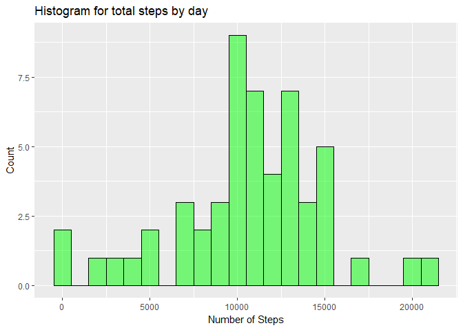

```r
total_by_day <- activity %>%
        group_by(date) %>%
        summarise(total_steps = sum(steps))

ggplot(data=total_by_day, aes(x=total_by_day$total_steps)) +
  geom_histogram(binwidth = 1000,
                 na.rm = TRUE,
                 col="black",
                 fill="green",
                 alpha = .5) +
  labs(title="Histogram for total steps by day", x="Number of Steps", y="Count")
```

#### 2) The mean and median of the total number of steps taken per day

```r
mean_steps_by_day = mean(total_by_day$total_steps, na.rm = TRUE)
median_steps_by_day = median(total_by_day$total_steps, na.rm = TRUE)
```

1. **Mean value:** 10766.19.
2. **Median value:** 10765.

## What is the average daily activity pattern?

#### 1) Make a time series plot of the 5-minute interval and the average number of steps taken, averaged across all days.

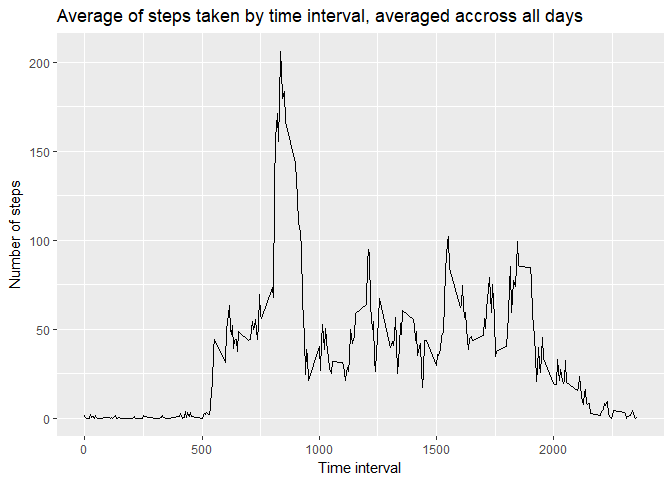

```r
avg_by_interval <- activity %>%
        group_by(interval) %>%
        summarise(avg_steps = mean(steps, na.rm = TRUE))

ggplot(data=avg_by_interval, aes(x=avg_by_interval$interval ,y=avg_by_interval$avg_steps)) +
  geom_line() +
  labs(title="Average of steps taken by time interval, averaged accross all days", x="Time interval", y="Number of steps")
```

#### 2) The 5-minute interval, that contains the maximum number of steps (on average across all days) is given by:

```r
max_interv <- filter(avg_by_interval, avg_steps == max(avg_steps))
```

1. **Interval:** 835
2. **Average of steps:** 206.1698113

## Imputing missing values

#### 1) Number of missing values in the dataset:

```r
missing_val <- sum(is.na(activity$steps))
```

**Missing values:** 2304

#### 2) Devise a strategy for filling in all of the missing values in the dataset:

NA values are replaced by the mean value for the corresponding 5-minute interval (averaged accross all days).

#### 3) Create a new dataset that is equal to the original dataset but with the missing data filled in:

```r
activity_filled <- activity %>%
                  group_by(interval) %>%
                  mutate(steps = ifelse(is.na(steps), mean(steps, na.rm = T), steps))
```

#### 4) Make a histogram of the total number of steps taken each day

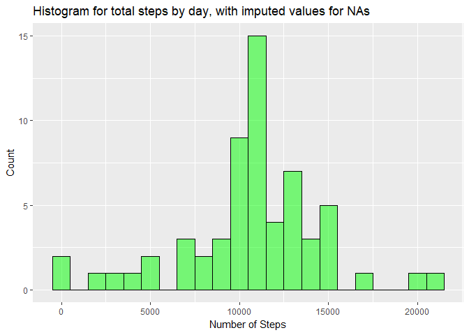

```r
total_by_day_filled <- activity_filled %>%
        group_by(date) %>%
        summarise(total_steps = sum(steps))

ggplot(data=total_by_day_filled, aes(x=total_steps)) +
  geom_histogram(binwidth = 1000,
                 na.rm = FALSE,
                 col="black",
                 fill="green",
                 alpha = .5) +
  labs(title="Histogram for total steps by day, with imputed values for NAs", x="Number of Steps", y="Count")
```

#### 5) Compute the mean and the median of these values.

```r
mean_steps_by_day_filled = mean(total_by_day_filled$total_steps, na.rm = TRUE)
median_steps_by_day_filled = median(total_by_day_filled$total_steps, na.rm = TRUE)
```

1. **Mean:** 10766.19.
2. **Median:** 10766.19.

#### 6) Do these values differ from the estimates from the first part of the assignment?

For the mean: no. But there is a slight difference in the value of the median.

## Are there differences in activity patterns between weekdays and weekends?

#### 1) Create a new factor variable in the dataset with two levels (“weekday” and “weekend”) indicating whether a given date is a weekday or weekend day.

```r
activity_weekdays <- activity_filled %>%
                    mutate(day_type = as.factor(if_else(wday(date, week_start = 1) < 6, "Weekday", "Weekend")))
```

#### 2) Compute average number of steps (over all days), by 5-minutes time-interval.

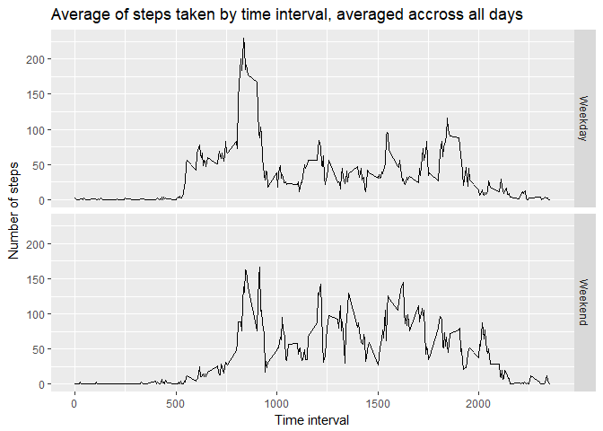

```r
intervMean_weekDay <- activity_weekdays %>%
        group_by(interval, day_type) %>%
        summarise(avg_steps = mean(steps, na.rm = TRUE))

ggplot(data=intervMean_weekDay, aes(x=interval ,y=avg_steps)) +
  geom_line() + facet_grid(day_type ~ .) + labs(title="Average of steps taken by time interval, averaged accross all days", x="Time interval", y="Number of steps")
```